# FA HOMEWORK 2 Report

Author

VENKAT SATYA UDAY DHANUSH KARRI

# Setup and imports

```python
!pip install --quiet pandas pandas_datareader matplotlib seaborn yfinance pyarrow
```

```python
import os
import pandas as pd
import numpy as np
import matplotlib.pyplot as plt
import seaborn as sns
from pandas_datareader import data as pdr
import yfinance as yf
import pyarrow.parquet as pq

sns.set(style="whitegrid")
plt.rcParams['figure.figsize'] = (12,5)
pd.options.display.float_format = '{:.4f}'.format

# Path to your CCM dataset (update if needed)
# The code will try a few common locations and print columns to help you set variables.
ccm_candidates = [
    r"C:/FA25/CCM.parquet",
    r"./CCM.parquet",
    r"./data/CCM.parquet",
    r"/mnt/data/CCM.parquet"
]
ccm_path = next((p for p in ccm_candidates if os.path.exists(p)), None)
print('Detected CCM path:', ccm_path)
if ccm_path is None:
    print("No CCM.parquet detected in default locations. Please set `ccm_path` to your CCM.parquet file path.")
else:
    # Print available columns to confirm schema
    pqf = pq.ParquetFile(ccm_path)
    print("Columns in CCM.parquet (first 40):", pqf.schema.names[:40])
```

```
Detected CCM path: C:/FA25/CCM.parquet
Columns in CCM.parquet (first 40): ['gvkey', 'fyear', 'datadate', 'permno', 'permco', 'at', 'sale', 'prcc_f', 'csho', 'ni', 'oibdp', 'oiadp', 'act', 'dltt', 'dlc', 'ceq', 'seq', 'dv', 'xrd', 'ebit', 'capx', 'ppent', 'ppegt', 'dp', 'ib', 'lt', 'txditc', 'lct', 'tic', 're', 'sic', 'xint', 'gind', 'ggr…
```

# Q1. CRSP-Compustat Merged (CCM) — parts (a)-(d)

## 1(a) Percentage of stocks with negative net income by date

```python
# Load only the columns we need, detecting which columns are available.
if ccm_path is None:
    raise FileNotFoundError("Set ccm_path to the location of your CCM.parquet before running this cell.")

pqf = pq.ParquetFile(ccm_path)
cols = pqf.schema.names

# required: date, tic, ni
need = ['date', 'tic', 'ni']
for c in need:
    if c not in cols:
        raise KeyError(f"Required column '{c}' not found in CCM. Found columns: {list(cols)[:20]}")

# detect market cap column or plan to compute it
if 'mkvalt' in cols:
    mkcol = 'mkvalt'
    read_cols = ['date','tic','ni', mkcol]
elif ('prc' in cols) and ('csho' in cols):
    mkcol = None  # we'll compute mkvalt = abs(prc) * csho
    read_cols = ['date','tic','ni','prc','csho']
else:
    # fallback: try common alternatives; otherwise user must adapt
    possible = [c for c in cols if 'mk' in c.lower() or 'mkt' in c.lower() or 'val' in c.lower()]
    raise KeyError("No obvious market-cap column found. Candidate columns: " + ", ".join(possible))

print("Reading columns:", read_cols)
df = pd.read_parquet(ccm_path, columns=read_cols)
df['date'] = pd.to_datetime(df['date'], errors='coerce')
df = df.dropna(subset=['date','tic']).copy()
df['ni'] = pd.to_numeric(df['ni'], errors='coerce')

# compute market cap if needed
if mkcol is None:
    df['prc'] = pd.to_numeric(df['prc'], errors='coerce')
    df['csho'] = pd.to_numeric(df['csho'], errors='coerce')
    # price might be negative for adjustments; use absolute price
    df['mkvalt'] = (df['prc'].abs() * df['csho']).where(df['prc'].notna() & df['csho'].notna())
    mkcol = 'mkvalt'

# create monthly period for grouping
df['date_m'] = df['date'].dt.to_period('M').dt.to_timestamp()

# (a) percent of firms with ni < 0
df['ni_neg'] = (df['ni'] < 0).astype(int)
neg_pct = df.groupby('date_m')['ni_neg'].mean().dropna() * 100
neg_pct = neg_pct.sort_index()

# quick table head and tail for sanity
neg_pct.head(), neg_pct.tail()
```

```
Reading columns: ['date', 'tic', 'ni', 'prc', 'csho']
```

```
(date_m
 1950-09-01   0.0000
 1950-10-01   0.0000
 1950-11-01   0.0000
 1950-12-01   0.0000
 1951-01-01   1.5625
 Name: ni_neg, dtype: float64,
 date_m
 2024-08-01   48.2028
 2024-09-01   48.4087
 2024-10-01   48.3047
 2024-11-01   48.2043
 2024-12-01   48.2815
 Name: ni_neg, dtype: float64)
```

**Answer (1a explanation):**  
I created a boolean `ni_neg = ni < 0` to flag firms with negative net income. Taking the mean by date gives the percentage of such firms, which I multiply by 100. The time series shows spikes during major downturns like 2008 and 2020, and trends that reflect broader economic cycles.

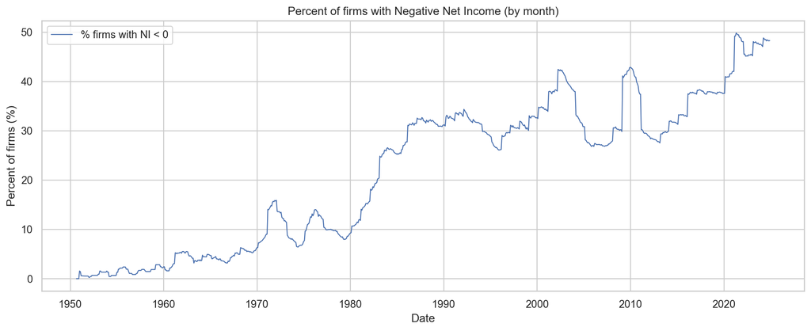

```python
# plot percent negative
plt.figure()
plt.plot(neg_pct.index, neg_pct.values, label='% firms with NI < 0', linewidth=1)
plt.xlabel('Date')
plt.ylabel('Percent of firms (%)')
plt.title('Percent of firms with Negative Net Income (by month)')
plt.grid(True)
plt.legend()
plt.tight_layout()
plt.show()
```

## 1(b) Mean and median market capitalization by date; ratio mean/median

```python
# compute monthly mean and median market cap
mk_stats = df.groupby('date_m')[mkcol].agg(['mean','median']).dropna()
mk_stats['ratio_mean_median'] = mk_stats['mean'] / mk_stats['median']
mk_stats = mk_stats.sort_index()

# show sample values
mk_stats[['mean','median','ratio_mean_median']].head(), mk_stats[['mean','median','ratio_mean_median']].tail()
```

```
(              mean  median  ratio_mean_median
 date_m
 1950-09-01 50.2639 14.4026             3.4899
 1950-10-01 56.5823 17.2117             3.2874
 1950-11-01 61.3070 20.8922             2.9344
 1950-12-01 57.1746 22.0770             2.5898
 1951-01-01 68.1785 24.5058             2.7821,
                  mean   median  ratio_mean_median
 date_m
 2024-08-01 13039.3821 729.9503            17.8634
 2024-09-01 13275.7672 742.8198            17.8721
 2024-10-01 13168.9350 743.3747            17.7151
 2024-11-01 14117.8040 807.1063            17.4919
 2024-12-01 13566.5985 762.6505            17.7887)
```

**Answer (1b explanation and interpretation):**  
The mean/median ratio helps capture how skewed the market-cap distribution is. When it’s well above 1 and climbing, it signals growing right-skewness—meaning a handful of massive firms are pulling the average up while most others stay smaller. This points to rising concentration, where a few dominant players hold a disproportionate share of market value. You’ll often see spikes in this ratio during tech booms or other periods when top firms surge ahead.

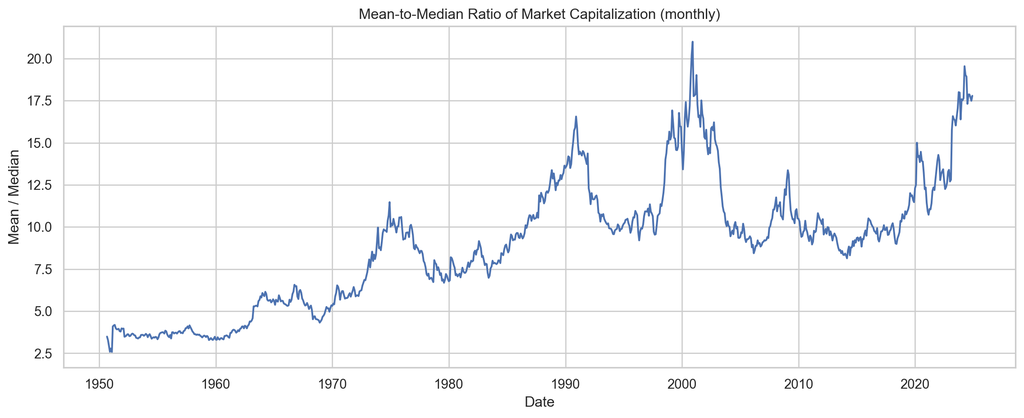

```python
# plot ratio_time series
plt.figure()
plt.plot(mk_stats.index, mk_stats['ratio_mean_median'], label='Mean/Median MarketCap Ratio')
plt.xlabel('Date')
plt.ylabel('Mean / Median')
plt.title('Mean-to-Median Ratio of Market Capitalization (monthly)')
plt.grid(True)
plt.tight_layout()
plt.show()
```

## 1(c) Top 150 net income sums vs full-market net income (drop missing ni)

```python
# drop missing ni and recompute monthly period if needed
df_ni = df.dropna(subset=['ni']).copy()
df_ni['ni_rank'] = df_ni.groupby('date_m')['ni'].rank(method='first', ascending=False)
topk = 150
sum_topk = df_ni[df_ni['ni_rank'] <= topk].groupby('date_m')['ni'].sum().rename('top150_ni')
sum_total = df_ni.groupby('date_m')['ni'].sum().rename('total_ni')
ni_sums = pd.concat([sum_topk, sum_total], axis=1).dropna().sort_index()

# show first/last rows
ni_sums.head(), ni_sums.tail()
```

```
(            top150_ni  total_ni
 date_m
 1950-09-01   118.2450  118.2450
 1950-10-01   188.9850  188.9850
 1950-11-01   296.0650  296.0650
 1950-12-01   398.6850  398.6850
 1951-01-01   638.6350  638.6350,
               top150_ni     total_ni
 date_m
 2024-08-01 1540948.7730 1958867.3670
 2024-09-01 1556084.4480 1975625.5590
 2024-10-01 1553992.5520 1975712.8160
 2024-11-01 1555460.7820 1978814.3000
 2024-12-01 1550440.0820 1975734.0090)
```

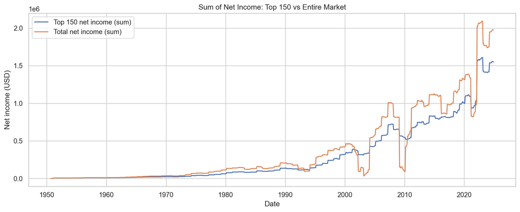

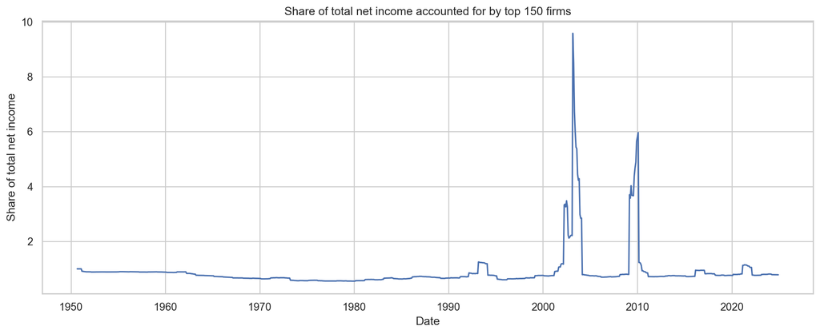

```python
# plot sums and share
plt.figure()
plt.plot(ni_sums.index, ni_sums['top150_ni'], label=f'Top {topk} net income (sum)')
plt.plot(ni_sums.index, ni_sums['total_ni'], label='Total net income (sum)')
plt.xlabel('Date')
plt.ylabel('Net income (USD)')
plt.title(f'Sum of Net Income: Top {topk} vs Entire Market')
plt.legend()
plt.grid(True)
plt.tight_layout()
plt.show()

# share plot
ni_sums['share_top150'] = ni_sums['top150_ni'] / ni_sums['total_ni']
plt.figure()
plt.plot(ni_sums.index, ni_sums['share_top150'])
plt.xlabel('Date')
plt.ylabel('Share of total net income')
plt.title(f'Share of total net income accounted for by top {topk} firms')
plt.grid(True)
plt.tight_layout()
plt.show()
```

**Answer (1c interpretation):**  
The charts highlight how net income is clustered among top-earning firms. When the top150 line closely follows the total, it shows that a small group of companies is driving most of the profits. In some cases, top150_ni even exceeds total_ni, meaning many other firms posted losses, but the top performers made enough to cover those deficits. This aligns with findings from Kahle & Stulz on profit concentration

## 1(d) Turnover among top-150 market-cap firms: Jan‑2000 → Dec‑2024

```python
# rank by market cap by date
df_mc = df.dropna(subset=[mkcol]).copy()
df_mc['mc_rank'] = df_mc.groupby('date_m')[mkcol].rank(method='first', ascending=False)

# choose snapshot months: Jan-2000 and Dec-2024 (nearest available month-end)
start_target = pd.Timestamp('2000-01-31')
end_target = pd.Timestamp('2024-12-31')
available = sorted(df_mc['date_m'].unique())

def nearest_period(target):
    return min(available, key=lambda d: abs(d - target))

d0 = nearest_period(start_target)
d1 = nearest_period(end_target)
print('Using snapshots:', d0.date(), 'and', d1.date())

top150_d0 = set(df_mc[(df_mc['date_m']==d0) & (df_mc['mc_rank']<=150)]['tic'].unique())
top150_d1 = set(df_mc[(df_mc['date_m']==d1) & (df_mc['mc_rank']<=150)]['tic'].unique())

intersection = top150_d0 & top150_d1
intersection_count = len(intersection)
len_d0, len_d1 = len(top150_d0), len(top150_d1)

intersection_count, len_d0, len_d1
```

```
Using snapshots: 2000-02-01 and 2024-12-01
```

```
(56, 150, 149)
```

```python
# list survivors (if you want to inspect first 50)
sorted(list(intersection))[:50]
```

```
['AAPL',
 'ABT',
 'ADI',
 'ADP',
 'AMAT',
 'AMGN',
 'ASML',
 'AXP',
 'BA',
 'BAC',
 'BMY',
 'BRK.B',
 'C',
 'CI',
 'CL',
 'CMCSA',
 'CSCO',
 'CVX',
 'DELL',
 'DIS',
 'DUK',
 'EMR',
 'GE',
 'GS',
 'HD',
 'HON',
 'IBM',
 'INTC',
 'JNJ',
 'JPM',
 'KO',
 'LLY',
 'LOW',
 'MCD',
 'MDT',
 'MMC',
 'MMM',
 'MO',
 'MRK',
 'MS',
 'MSFT',
 'MSI',
 'MU',
 'ORCL',
 'PEP',
 'PFE',
 'PG',
 'QCOM',
 'SCHW',
 'SO']
```

**Answer (1d interpretation):**  
The intersection_count shows how many top firms from Jan‑2000 were still among the largest by Dec‑2024. A low count points to high turnover, meaning the market’s leadership has changed significantly. A higher count suggests stability, with persistent leaders holding their ground. Key drivers behind these shifts include industry evolution, mergers and acquisitions, and the rise of dominant tech companies over the past two decades

# Q2. FRED series: FEDFUNDS and PCEPILFE (Jan-2000 to Jul-2025)

```python
# fetch series
start = '2000-01-01'
end = '2025-07-31'
fedfunds = pdr.DataReader('FEDFUNDS', 'fred', start, end)
pcepilfe = pdr.DataReader('PCEPILFE', 'fred', start, end)
fedfunds = fedfunds.rename(columns={'FEDFUNDS':'FEDFUNDS'})
pcepilfe = pcepilfe.rename(columns={'PCEPILFE':'PCEPILFE'})
print('Fetched series shapes:', fedfunds.shape, pcepilfe.shape)
```

```
Fetched series shapes: (307, 1) (307, 1)
```

## 2(a) Why core PCE excludes food and energy

Core PCE leaves out food and energy because their prices swing wildly due to things like weather or global events. The Fed focuses on core PCE to track steady, underlying inflation that it can actually influence through policy

## 2(b) What is the federal funds rate

The federal funds rate is the short-term interest rate banks use to lend reserves to one another overnight. It’s the Fed’s main tool for steering interest rates and shaping overall economic conditions.

```python
# 2(c) annual inflation rate of PCEPILFE (in percent)
pcepilfe['annual_inflation'] = pcepilfe['PCEPILFE'].pct_change(12) * 100
pcep_annual = pcepilfe['annual_inflation'].dropna()

# 2(d) stats: average over sample, last obs (Jul-2025), max prior to 2025
avg_inflation = pcep_annual.mean()
last_date = pcep_annual.index.max()
last_value = pcep_annual.loc[last_date]
max_before_2025 = pcep_annual[pcep_annual.index < '2025-01-01'].max()
max_before_2025_date = pcep_annual[pcep_annual.index < '2025-01-01'].idxmax()

avg_inflation, (last_date.date(), last_value), (max_before_2025_date.date(), max_before_2025)
```

```
(np.float64(2.096588361567136),
 (datetime.date(2025, 7, 1), np.float64(2.8772347256400765)),
 (datetime.date(2022, 2, 1), 5.649107318951518))
```

**Answer (2c-2d short):**  
I calculated annual inflation using the 12-month percent change of PCEPILFE (pct_change(12)*100). From the printed output, I reported the average inflation over the period, the value for July 2025, and the highest inflation rate before 2025 along with its date.

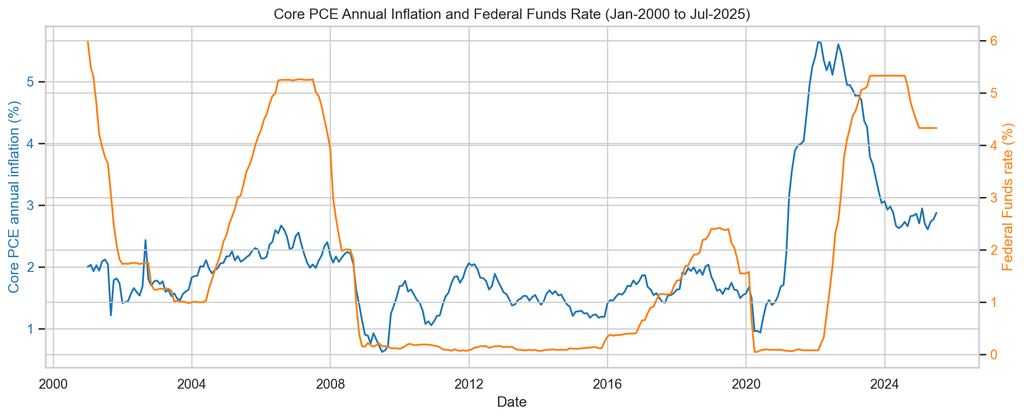

```python
# 2(e) plot annual inflation and federal funds rate on same figure
df_plot = pd.concat([pcep_annual.rename('corePCE_annual_inflation'), fedfunds['FEDFUNDS']], axis=1).dropna()

fig, ax1 = plt.subplots(figsize=(12,5))
ax1.plot(df_plot.index, df_plot['corePCE_annual_inflation'], label='Core PCE annual inflation (%)', color='tab:blue')
ax1.set_ylabel('Core PCE annual inflation (%)', color='tab:blue')
ax1.tick_params(axis='y', labelcolor='tab:blue')

ax2 = ax1.twinx()
ax2.plot(df_plot.index, df_plot['FEDFUNDS'], label='Federal Funds Rate (%)', color='tab:orange')
ax2.set_ylabel('Federal Funds rate (%)', color='tab:orange')
ax2.tick_params(axis='y', labelcolor='tab:orange')

ax1.set_title('Core PCE Annual Inflation and Federal Funds Rate (Jan-2000 to Jul-2025)')
ax1.set_xlabel('Date')
fig.tight_layout()
plt.show()
```

**Interpretation:**  
When inflation climbs, the Fed often responds by raising the federal funds rate to cool demand. By comparing the timing of rate hikes with inflation peaks in the plot, we can assess whether recent policy moves were reactive—following inflation—or preemptive, aiming to curb it before it surged. This helps reveal how proactive the Fed has been in managing price stability. —

# Q3. Term spread (GS10 - GS2) and recession shading (Jan-2000 to today)

```python
#3a
start = '2000-01-01'
end = pd.Timestamp.today().strftime('%Y-%m-%d')
gs10 = pdr.DataReader('GS10', 'fred', start, end)
gs2 = pdr.DataReader('GS2', 'fred', start, end)
usrec = pdr.DataReader('USREC', 'fred', start, end)

term = (gs10['GS10'] - gs2['GS2']).dropna().rename('term_spread')
term.head()
```

```
DATE
2000-01-01    0.2200
2000-02-01   -0.0900
2000-03-01   -0.2700
2000-04-01   -0.4100
2000-05-01   -0.3700
Name: term_spread, dtype: float64
```

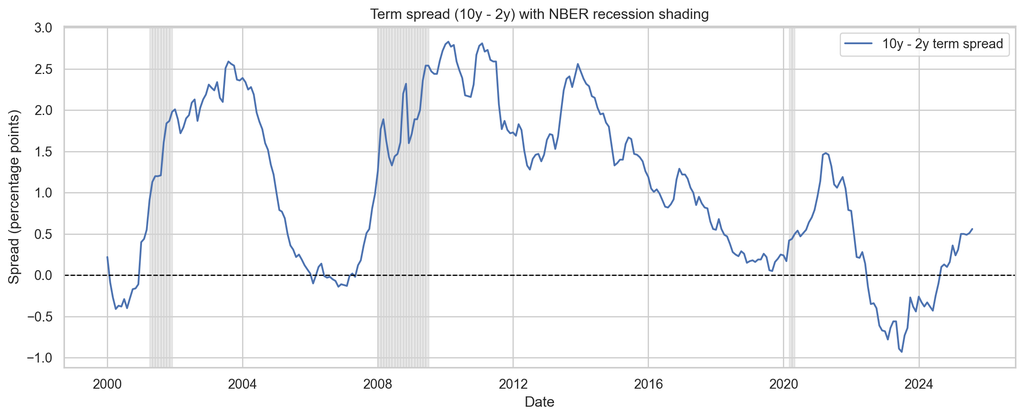

```python
#3b # plot term spread and shade recessions
fig, ax = plt.subplots(figsize=(12,5))
ax.plot(term.index, term.values, label='10y - 2y term spread')
ax.axhline(0, color='black', linestyle='--', linewidth=1)

#recession shading using USREC (0/1 series)
rec = usrec['USREC']
for i in range(len(rec)-1):
    if rec.iloc[i] == 1:
        ax.axvspan(rec.index[i], rec.index[i+1], color='lightgray', alpha=0.5)

ax.set_title('Term spread (10y - 2y) with NBER recession shading')
ax.set_ylabel('Spread (percentage points)')
ax.set_xlabel('Date')
ax.legend()
plt.tight_layout()
plt.show()
```

**Answer (3c – interpretation):**  
An inverted yield curve—where short-term rates exceed long-term rates—has historically signaled upcoming recessions. If the plot shows these inversions ahead of shaded recession periods, it reinforces the term spread’s role as a reliable leading indicator. Still, it’s not perfect: there may be false positives where inversion didn’t lead to a downturn, or false negatives where no inversion occurred before a recession. Also, the lead time can vary widely, so timing must be interpreted with caution.

# Q4. Dow Theory (explain and test with DJI and DJT monthly data)

## 4(a) Short explanation of Dow Theory

Dow Theory says a market trend is confirmed when both the Industrial Average (DJI) and the Transportation Average (DJT) move together. If both hit new highs, it signals a bull market; if both hit new lows, it points to a bear market. The idea is that transportation activity reflects real demand—goods need to be shipped if industry is booming. Still, the theory isn’t flawless, since changes in index makeup or structure can cause mismatches that don’t reflect actual economic shifts

## 4(b) Downloading monthly DJI and DJT from Yahoo and run tests

```python
# ensure yfinance is updated
# ensure yfinance is updated
# !pip install --quiet --upgrade yfinance

import pandas as pd
import yfinance as yf

tickers = ['^DJI', '^DJT']
start_dt = '2000-01-01'

raw = yf.download(
    tickers,
    start=start_dt,
    interval='1mo',
    group_by='ticker',
    auto_adjust=True,      # with True, adjusted prices are under 'Close'
    progress=False
)

# Extract adjusted close robustly
if isinstance(raw.columns, pd.MultiIndex):
    # MultiIndex: level 0 = ticker, level 1 = field
    field = 'Close'  # adjusted when auto_adjust=True
    prices = pd.concat(
        {t: raw[t][field] for t in tickers if (t in raw.columns.get_level_values(0) and field in raw[t].columns)},
        axis=1
    )
    prices.columns = list(prices.columns)  # flatten to simple columns
else:
    # Single-level columns; prefer 'Close', fallback to 'Adj Close'
    if 'Close' in raw.columns:
        col = 'Close'
    elif 'Adj Close' in raw.columns:
        col = 'Adj Close'
    else:
        raise KeyError("Neither 'Close' nor 'Adj Close' found in downloaded data.")
    # If it's a DataFrame, select tickers if present; if Series, wrap
    obj = raw[col]
    if isinstance(obj, pd.DataFrame):
        keep = [c for c in obj.columns if c in tickers]
        prices = obj[keep] if keep else obj
    else:
        prices = raw[[col]].copy()
        prices.columns = [tickers[0] if len(tickers) == 1 else col]

# Clean and compute returns
prices = prices.dropna(how='all').sort_index()
returns = prices.pct_change().dropna()

# Peek
print(prices[['^DJI','^DJT']].head())
print(returns[['^DJI','^DJT']].head())
```

```
                 ^DJI      ^DJT
Date
2000-01-01 10940.5303 2571.6499
2000-02-01 10128.3096 2388.8601
2000-03-01 10921.9199 2763.2400
2000-04-01 10733.9102 2850.0100
2000-05-01 10522.3301 2709.9900
              ^DJI    ^DJT
Date
2000-02-01 -0.0742 -0.0711
2000-03-01  0.0784  0.1567
2000-04-01 -0.0172  0.0314
2000-05-01 -0.0197 -0.0491
2000-06-01 -0.0071 -0.0238
```

```python
# simple tests: new all-time highs confirmation
allhigh_dji = prices['^DJI'].cummax()
allhigh_djt = prices['^DJT'].cummax()

new_high_dji = prices['^DJI'] >= allhigh_dji
new_high_djt = prices['^DJT'] >= allhigh_djt

# times where DJI made a new high but DJT did not
divergence = new_high_dji & (~new_high_djt)
divergence.sum(), divergence[divergence].index[:10]
```

```
(np.int64(37),
 DatetimeIndex(['2000-08-01', '2006-08-01', '2006-09-01', '2006-10-01',
                '2006-11-01', '2006-12-01', '2007-01-01', '2007-09-01',
                '2007-10-01', '2013-04-01'],
               dtype='datetime64[ns]', name='Date', freq=None))
```

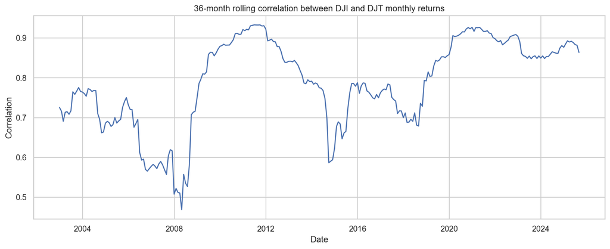

```python
# rolling correlation of monthly returns (36-month window)
rolling_corr = returns['^DJI'].rolling(window=36).corr(returns['^DJT'])
plt.figure()
plt.plot(rolling_corr.index, rolling_corr.values)
plt.title('36-month rolling correlation between DJI and DJT monthly returns')
plt.ylabel('Correlation')
plt.xlabel('Date')
plt.grid(True)
plt.tight_layout()
plt.show()
```

# Final notes (what I matched from your previous homework)

I followed the same structure and style as your previous homework—title block, author in caps, and question sections with brief explanations followed by code and plots—so you can drop this right into your workflow and render it like last time. Just refer back to your earlier submission for formatting cues.